# Sesión 7 – Explicación detallada del bucle for para leer archivos

# ¿Qué es una lista en R?

Una **lista** es una estructura versátil que puede almacenar diferentes tipos de objetos, incluyendo vectores, `data.frame`, strings, números e incluso otras listas.

```r
# Crear una lista simple
mi_lista <- list(
  nombre = "Ana",
  edad = 30,
  notas = c(8.5, 9.0, 10),
  aprobado = TRUE
)

mi_lista
```

```
## $nombre
## [1] "Ana"
##
## $edad
## [1] 30
##
## $notas
## [1]  8.5  9.0 10.0
##
## $aprobado
## [1] TRUE
```

## 🎯 Acceso a elementos dentro de una lista

```r
# Acceso por nombre (con doble corchete)
mi_lista[["notas"]]
```

```
## [1]  8.5  9.0 10.0
```

```r
# Acceso por posición
mi_lista[[2]]
```

```
## [1] 30
```

```r
# Acceso por nombre usando el operador $
mi_lista$nombre
```

```
## [1] "Ana"
```

## 🧾 Almacenar `data.frames` dentro de una lista

Las listas también permiten almacenar múltiples tablas:

```r
lista_df <- list(mtcars, ToothGrowth)
```

# 🔁 `apply()` – Bucle vectorizado para matrices y `data.frames`

La función `apply()` permite aplicar una operación sobre las **filas** o **columnas** de un objeto tipo `matrix` o `data.frame`.

### 📚 Sintaxis

```r
apply(X, MARGIN, FUN, ...)
```

- `X`: matriz o `data.frame`
- `MARGIN`: `1` para aplicar por filas, `2` para columnas
- `FUN`: la función que deseas aplicar (por ejemplo: `mean`, `sum`, `summary`, etc.)

## 🧮 Ejemplos prácticos

### ➕ Calcular promedios por columna

```r
apply(mtcars, 2, mean)
```

```
##        mpg        cyl       disp         hp       drat         wt       qsec
##  20.090625   6.187500 230.721875 146.687500   3.596563   3.217250  17.848750
##         vs         am       gear       carb
##   0.437500   0.406250   3.687500   2.812500
```

### 📊 Obtener resumen estadístico por columna

```r
apply(mtcars, 2, summary)
```

```
##              mpg    cyl     disp       hp     drat      wt     qsec     vs
## Min.    10.40000 4.0000  71.1000  52.0000 2.760000 1.51300 14.50000 0.0000
## 1st Qu. 15.42500 4.0000 120.8250  96.5000 3.080000 2.58125 16.89250 0.0000
## Median  19.20000 6.0000 196.3000 123.0000 3.695000 3.32500 17.71000 0.0000
## Mean    20.09062 6.1875 230.7219 146.6875 3.596563 3.21725 17.84875 0.4375
## 3rd Qu. 22.80000 8.0000 326.0000 180.0000 3.920000 3.61000 18.90000 1.0000
## Max.    33.90000 8.0000 472.0000 335.0000 4.930000 5.42400 22.90000 1.0000
##              am   gear   carb
## Min.    0.00000 3.0000 1.0000
## 1st Qu. 0.00000 3.0000 2.0000
## Median  0.00000 4.0000 2.0000
## Mean    0.40625 3.6875 2.8125
## 3rd Qu. 1.00000 4.0000 4.0000
## Max.    1.00000 5.0000 8.0000
```

## ❌ Alternativa manual (no recomendada)

```r
mean(mtcars$wt)
```

```
## [1] 3.21725
```

```r
mean(mtcars$gear)
```

```
## [1] 3.6875
```

```r
mean(mtcars$mpg)
```

```
## [1] 20.09062
```

✏️ Como puedes ver, hacerlo manualmente requiere muchas líneas.  
Con `apply()`, el mismo resultado se logra con una sola línea, haciendo tu código más limpio y eficiente.

## lapply() – bucle para listas

```r
# Devuelve una lista
my_list <-list("Lisa","Pedro","Alberto")
```

Contar numero de caracteres con funcion nchar par todos los elementos de la lista

```r
lapply(my_list, nchar)
```

```
## [[1]]
## [1] 4
##
## [[2]]
## [1] 5
##
## [[3]]
## [1] 7
```

De otra forma tendría que realizarse la operación uno por uno

```r
nchar(my_list[[1]])
```

```
## [1] 4
```

```r
nchar(my_list[[2]])
```

```
## [1] 5
```

```r
nchar(my_list[[3]])
```

```
## [1] 7
```

## 🔁 Uso de bucle `for` para leer múltiples archivos

En esta sección explicaremos paso a paso cómo funciona el siguiente bloque de código. El objetivo es leer varios archivos `.csv` de forma automática y almacenarlos en una lista.

```r
# Crear lista vacía para almacenar resultados del bucle
df_list <- list()
# Almacenar archivos en vector filenames
filenames <- list.files()
for (ii in 1:10) {
  # Leer archivos con read.csv
  df_list[[ii]] <- read.csv(filenames[ii])
}

df_list
```

### 🧠 ¿Qué hace este código?

1. **`df_list <- list()`**
   - Se crea una lista vacía llamada `df_list`.
   - Esta lista servirá como contenedor para guardar los resultados que obtengamos dentro del bucle.
2. **`for (ii in 1:10)`**
   - Aquí se define un bucle que se ejecutará 10 veces.
   - La variable `ii` irá tomando valores del 1 al 10 automáticamente:
     - En la **primera vuelta**, `ii = 1`
     - En la **segunda vuelta**, `ii = 2`
     - …
     - En la **décima vuelta**, `ii = 10`
   - En cada vuelta, se ejecuta el bloque de código que está entre llaves `{}`.
3. **`read.csv(filenames[ii])`**
   - `filenames` es un vector que contiene los nombres de los archivos `.csv` que queremos leer.
   - En cada vuelta, `filenames[ii]` accede al archivo correspondiente según el valor de `ii`.
     - Por ejemplo, si `ii = 3`, se leerá el archivo `filenames[3]`.
   - `read.csv()` carga ese archivo y lo convierte en un `data.frame`.
4. **`df_list[[ii]] <- ...`**
   - El resultado de `read.csv()` se guarda dentro de la lista `df_list` en la posición `ii`.
   - Así, el primer archivo va a `df_list[[1]]`, el segundo a `df_list[[2]]`, y así sucesivamente.

### 📦 Resultado final

Después de que el bucle termina:

- `df_list` contiene **10 objetos tipo `data.frame`**, uno por cada archivo leído.
- Puedes acceder a cada uno usando `df_list[[1]]`, `df_list[[2]]`, …, `df_list[[10]]`.

### 🎯 ¿Por qué es útil este patrón?

- Automatiza la lectura de múltiples archivos sin repetir código.
- Organiza los resultados en una lista accesible.
- Es fácil de adaptar para leer 5, 100 o más archivos cambiando el rango del bucle.

# 🛠 Crear múltiples gráficos con `for` loop

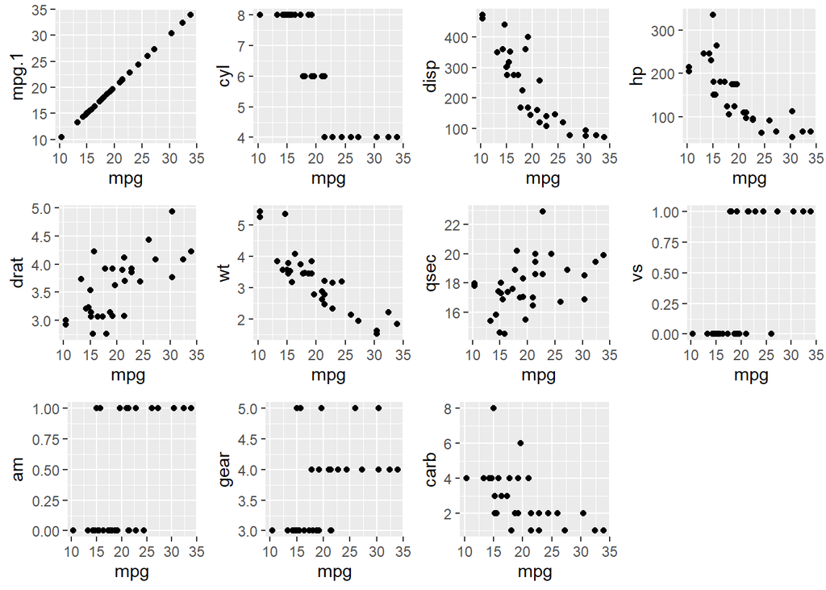

```r
library(ggplot2)
library(cowplot)
plot_list <- list()

for (ii in 1:ncol(mtcars)) {
  axis_titles <- colnames(mtcars[, c(1, ii)])
  my_df <- mtcars[, c(1, ii)]
  colnames(my_df) <- c("x_axis", "y_axis")

  plot_list[[ii]] <- ggplot(my_df, aes(x = x_axis, y = y_axis)) +
    geom_point() +
    xlab(axis_titles[1]) +
    ylab(axis_titles[2])
}

cowplot::plot_grid(plotlist = plot_list)
```

# 🧠 ¿Cuándo usar `apply`, `lapply`, `for`?

| Tipo | Ideal para… | Devuelve |
| --- | --- | --- |
| `for` | Control total / pasos secuenciales | Nada (o manual) |
| `apply` | Operar sobre filas o columnas | Vector / matriz |
| `lapply` | Operar sobre listas | Lista |